# Tema 2.1 - Visualización

Roi Naveiro

2022-12-18

## Análisis Exploratioro de los Datos

- El arte de observar los datos, generar hipótesis y testearlas.
- **Objetivo**: generar preguntas prometedoras para, posteriormente, explorarlas en mayor profunidad

## tidyverse

Queremos analizar los datos de forma **reproducible**

[figure not shown]

[tidyverse.org](https://www.tidyverse.org/)

- Tidyverse es una colección de paquetes de R para ciencia de datos
- Todos los paquetes comparten una filosofía y una gramática comunes

# El objeto tibble

## El objeto tibble

- Todos los paquetes de tidyverse trabajan con tibbles
- El objeto tibble es similar al data frame que hemos visto
- No obstante, incluye algunas novedades que lo hacen especialmente conveniente para el análisis de datos.
- Antes de empezar, debemos cargar la librería `tidyverse`

```r
library(tidyverse)
```

## Creación de tibbles

- Podemos crear un tibble desde un dataframe

```r
as_tibble(iris)
```

```
## # A tibble: 150 × 5
##    Sepal.Length Sepal.Width Petal.Length Petal.Width Species
##           <dbl>       <dbl>        <dbl>       <dbl> <fct>
##  1          5.1         3.5          1.4         0.2 setosa
##  2          4.9         3            1.4         0.2 setosa
##  3          4.7         3.2          1.3         0.2 setosa
##  4          4.6         3.1          1.5         0.2 setosa
##  5          5           3.6          1.4         0.2 setosa
##  6          5.4         3.9          1.7         0.4 setosa
##  7          4.6         3.4          1.4         0.3 setosa
##  8          5           3.4          1.5         0.2 setosa
##  9          4.4         2.9          1.4         0.2 setosa
## 10          4.9         3.1          1.5         0.1 setosa
## # … with 140 more rows
```

## Creación de tibbles

- Podemos crear un tibble desde vectores, de manera similar a cómo hicimos con dataframes

```r
dt <- tibble(
  p = c("A", "B", "C", "D", "E"),
  x = 1:5,
  y = 2,
  z = x + y
)
dt
```

```
## # A tibble: 5 × 4
##   p         x     y     z
##   <chr> <int> <dbl> <dbl>
## 1 A         1     2     3
## 2 B         2     2     4
## 3 C         3     2     5
## 4 D         4     2     6
## 5 E         5     2     7
```

## Creación de tibbles

- Podemos dar nombres complejos a las columnas de un tibble

```r
dt <- tibble(
  `Número de :)` = 1:5,
  ` ` = 2,
  `300` = 300
)
dt
```

```
## # A tibble: 5 × 3
##   `Número de :)`   ` ` `300`
##            <int> <dbl> <dbl>
## 1              1     2   300
## 2              2     2   300
## 3              3     2   300
## 4              4     2   300
## 5              5     2   300
```

## Tibbles vs Data Frames

### Printing

Los tibble tienen un método `print` refinado que por defecto solo muestra las 10 primeras filas

```r
iris
```

```
##     Sepal.Length Sepal.Width Petal.Length Petal.Width    Species
## 1            5.1         3.5          1.4         0.2     setosa
## 2            4.9         3.0          1.4         0.2     setosa
## 3            4.7         3.2          1.3         0.2     setosa
## 4            4.6         3.1          1.5         0.2     setosa
## 5            5.0         3.6          1.4         0.2     setosa
## 6            5.4         3.9          1.7         0.4     setosa
## 7            4.6         3.4          1.4         0.3     setosa
## 8            5.0         3.4          1.5         0.2     setosa
## 9            4.4         2.9          1.4         0.2     setosa
## 10           4.9         3.1          1.5         0.1     setosa
## 11           5.4         3.7          1.5         0.2     setosa
## 12           4.8         3.4          1.6         0.2     setosa
## 13           4.8         3.0          1.4         0.1     setosa
## 14           4.3         3.0          1.1         0.1     setosa
```

[output cut: 136 more lines]

## Tibbles vs Data Frames

### Printing

```r
dt <- as_tibble(iris)
```

## Tibbles vs Data Frames

### Printing

Esto es así para no sobrecargar la consola con los prints. ¿Y si necesitamos más de 10 filas? ¡PIPES!

```r
dt %>% print(n=11, width=Inf)
```

```
## # A tibble: 150 × 5
##    Sepal.Length Sepal.Width Petal.Length Petal.Width Species
##           <dbl>       <dbl>        <dbl>       <dbl> <fct>
##  1          5.1         3.5          1.4         0.2 setosa
##  2          4.9         3            1.4         0.2 setosa
##  3          4.7         3.2          1.3         0.2 setosa
##  4          4.6         3.1          1.5         0.2 setosa
##  5          5           3.6          1.4         0.2 setosa
##  6          5.4         3.9          1.7         0.4 setosa
##  7          4.6         3.4          1.4         0.3 setosa
##  8          5           3.4          1.5         0.2 setosa
##  9          4.4         2.9          1.4         0.2 setosa
## 10          4.9         3.1          1.5         0.1 setosa
## 11          5.4         3.7          1.5         0.2 setosa
## # … with 139 more rows
```

## Tibbles vs Data Frames

### Printing

En RStudio, esto nos permite explorar el dataframe en una pantalla diferente.

```r
dt %>% View()
```

## Tibbles vs Data Frames

### Subsetting

Para seleccionar una única variable usar `$` (por nombre) o `[[` (por nombre o posición)

```r
# Extraer por nombre
dt$Species[1:10]
```

```
##  [1] setosa setosa setosa setosa setosa setosa setosa setosa setosa setosa
## Levels: setosa versicolor virginica
```

```r
# Extraer por posicion
dt[[5]][1:10]
```

```
##  [1] setosa setosa setosa setosa setosa setosa setosa setosa setosa setosa
## Levels: setosa versicolor virginica
```

## Tibbles vs Data Frames

### Subsetting

También en pipe

```r
dt %>% .$Species
```

```
##   [1] setosa     setosa     setosa     setosa     setosa     setosa
##   [7] setosa     setosa     setosa     setosa     setosa     setosa
##  [13] setosa     setosa     setosa     setosa     setosa     setosa
##  [19] setosa     setosa     setosa     setosa     setosa     setosa
##  [25] setosa     setosa     setosa     setosa     setosa     setosa
##  [31] setosa     setosa     setosa     setosa     setosa     setosa
##  [37] setosa     setosa     setosa     setosa     setosa     setosa
##  [43] setosa     setosa     setosa     setosa     setosa     setosa
##  [49] setosa     setosa     versicolor versicolor versicolor versicolor
##  [55] versicolor versicolor versicolor versicolor versicolor versicolor
##  [61] versicolor versicolor versicolor versicolor versicolor versicolor
##  [67] versicolor versicolor versicolor versicolor versicolor versicolor
##  [73] versicolor versicolor versicolor versicolor versicolor versicolor
##  [79] versicolor versicolor versicolor versicolor versicolor versicolor
##  [85] versicolor versicolor versicolor versicolor versicolor versicolor
##  [91] versicolor versicolor versicolor versicolor versicolor versicolor
##  [97] versicolor versicolor versicolor versicolor virginica  virginica
## [103] virginica  virginica  virginica  virginica  virginica  virginica
## [109] virginica  virginica  virginica  virginica  virginica  virginica
## [115] virginica  virginica  virginica  virginica  virginica  virginica
## [121] virginica  virginica  virginica  virginica  virginica  virginica
## [127] virginica  virginica  virginica  virginica  virginica  virginica
## [133] virginica  virginica  virginica  virginica  virginica  virginica
## [139] virginica  virginica  virginica  virginica  virginica  virginica
## [145] virginica  virginica  virginica  virginica  virginica  virginica
## Levels: setosa versicolor virginica
```

## Tibbles vs Data Frames

Convertir de nuevo a data frame

```r
class( as.data.frame(dt) )
```

```
## [1] "data.frame"
```

## Visualización

## Visualización

Creación y estudio de representaciones visuales de los datos

- En esta parte del curso nos centraremos en aprender a manejar `ggplot2` un paquete de tidyverse realmente útil para la visualización
- EDA incluye, además de visualización, la manipulación de datos
- EDA combina la visualización y la manipulación con la curiosidad y el escepticismo de cada uno para preguntar y responder cuestiones interesantes acerca de los datos

## ggplot2

- **ggplot2** es el paquete de visualización de tidyverse
- `gg` significa Grammar of Graphics
- Está inspirado en el libreo **Grammar of Graphics** de Leland Wilkinson

[figure not shown]

GG: herramienta que permite describir de forma secuencial los componentes de un gráfico

## Visualización

Primero cargamos las librerías necesarias

```r
library(tidyverse)
library(gapminder)
```

Ojeamos los datos

```r
glimpse(gapminder)
```

```
## Rows: 1,704
## Columns: 6
## $ country   <fct> "Afghanistan", "Afghanistan", "Afghanist…
## $ continent <fct> Asia, Asia, Asia, Asia, Asia, Asia, Asia…
## $ year      <int> 1952, 1957, 1962, 1967, 1972, 1977, 1982…
## $ lifeExp   <dbl> 28.801, 30.332, 31.997, 34.020, 36.088, …
## $ pop       <int> 8425333, 9240934, 10267083, 11537966, 13…
## $ gdpPercap <dbl> 779.4453, 820.8530, 853.1007, 836.1971, …
```

# Visualización: Visualizando la relación entre PIB per capita y esperanza de vida

## Primera visualización

¿Qué hace cada línea?

```r
gapminder67 <- gapminder %>% filter(year == "1967")  #<<
ggplot(gapminder67,
     aes(gdpPercap, lifeExp, size = pop, color = continent)) +
     geom_point() +
     scale_x_log10()  # convert to log scale
```

## Primera visualización

¿Qué hace cada línea?

```r
gapminder67 <- gapminder %>% filter(year == "1967")
ggplot(gapminder67,
     aes(gdpPercap, lifeExp, size = pop, color = continent)) +
     geom_point() +  #<<
     scale_x_log10()  # convert to log scale
```

## Primera visualización

¿Qué hace cada línea?

```r
gapminder67 <- gapminder %>% filter(year == "1967")
ggplot(gapminder67,  #<<
     aes(gdpPercap, lifeExp, size = pop, color = continent)) +  #<<
     geom_point() +
     scale_x_log10()
```

## Funcionamiento `ggplot2`

- La estructura del código de `ggplot2` es la siguiente

```r
ggplot(data = [dataset],
       mapping = aes(x = [x-variable], y = [y-variable])) +
   geom_xxx() +
   otras opciones
```

- El `mapping` define como las variables son mapeadas a propiedades visuales del gráfico.

Documentación [ggplot2.tidyverse.org](http://ggplot2.tidyverse.org/)

## Funcionamiento `ggplot2`

- Alternativamente

```r
ggplot(data = [dataset]) +
   geom_xxx( mapping = aes(x = [x-variable], y = [y-variable]) ) +
   other options
```

## Paso a Paso

Ojeamos los datos

```r
glimpse(gapminder)
```

```
## Rows: 1,704
## Columns: 6
## $ country   <fct> "Afghanistan", "Afghanistan", "Afghanist…
## $ continent <fct> Asia, Asia, Asia, Asia, Asia, Asia, Asia…
## $ year      <int> 1952, 1957, 1962, 1967, 1972, 1977, 1982…
## $ lifeExp   <dbl> 28.801, 30.332, 31.997, 34.020, 36.088, …
## $ pop       <int> 8425333, 9240934, 10267083, 11537966, 13…
## $ gdpPercap <dbl> 779.4453, 820.8530, 853.1007, 836.1971, …
```

Miramos `?gapminder`

## Paso a Paso

```r
gapminder67 <- gapminder %>% filter(year == "1967")
gapminder67
```

```
## # A tibble: 142 × 6
##    country     continent  year lifeExp      pop gdpPercap
##    <fct>       <fct>     <int>   <dbl>    <int>     <dbl>
##  1 Afghanistan Asia       1967    34.0 11537966      836.
##  2 Albania     Europe     1967    66.2  1984060     2760.
##  3 Algeria     Africa     1967    51.4 12760499     3247.
##  4 Angola      Africa     1967    36.0  5247469     5523.
##  5 Argentina   Americas   1967    65.6 22934225     8053.
##  6 Australia   Oceania    1967    71.1 11872264    14526.
##  7 Austria     Europe     1967    70.1  7376998    12835.
##  8 Bahrain     Asia       1967    59.9   202182    14805.
##  9 Bangladesh  Asia       1967    43.5 62821884      721.
## 10 Belgium     Europe     1967    70.9  9556500    13149.
## # … with 132 more rows
```

## Paso a Paso

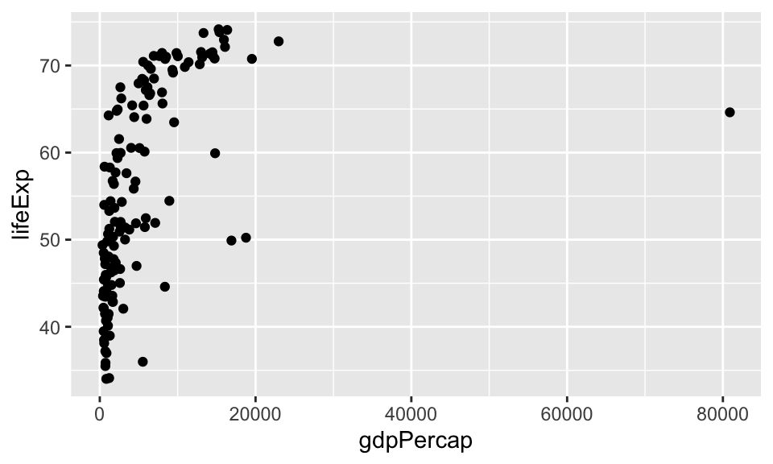

```r
ggplot(gapminder67, aes(x = gdpPercap, y = lifeExp) ) +
     geom_point()
```

¿Cómo describirías la relación entre pib per capita y esperanza de vida?

## Paso a Paso

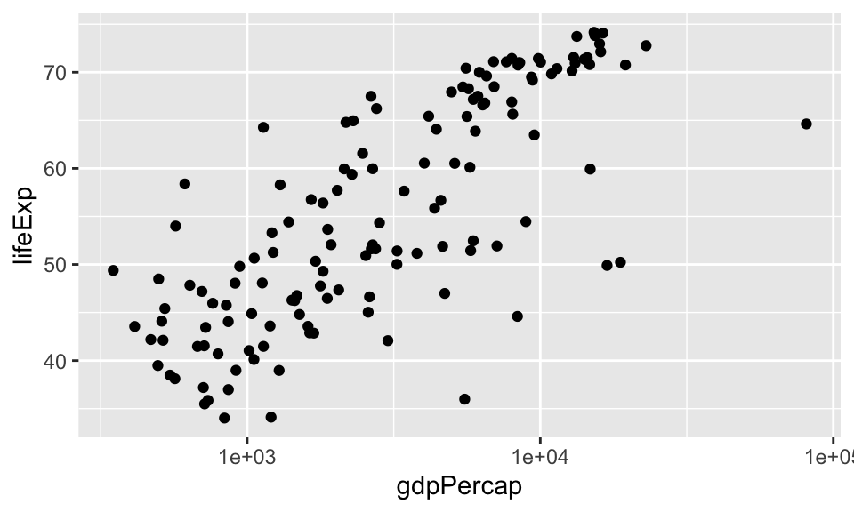

```r
ggplot(gapminder67, aes(x = gdpPercap, y = lifeExp) ) +
     geom_point() +
     scale_x_log10()  #<<
```

¿Cómo describirías la relación entre pib per capita y esperanza de vida?

## Variables adicionales

Es posible que queramos representar más de dos variables. Podemos hacerlo a través de otros elementos del gráfico (en mapping usamos solo x e y, podemos añadir más)

- **aesthetics**:
  - shape
  - color
  - size
  - alpha (transparencia)
- **faceting**: varias gráficas

# Visualización: Aesthetics

## Aesthetics

Las siguientes características visuales del gráfico pueden ser utilizadas para representar una variable extra

- shape
- color
- size
- alpha (transparencia)

## Representamos el continente

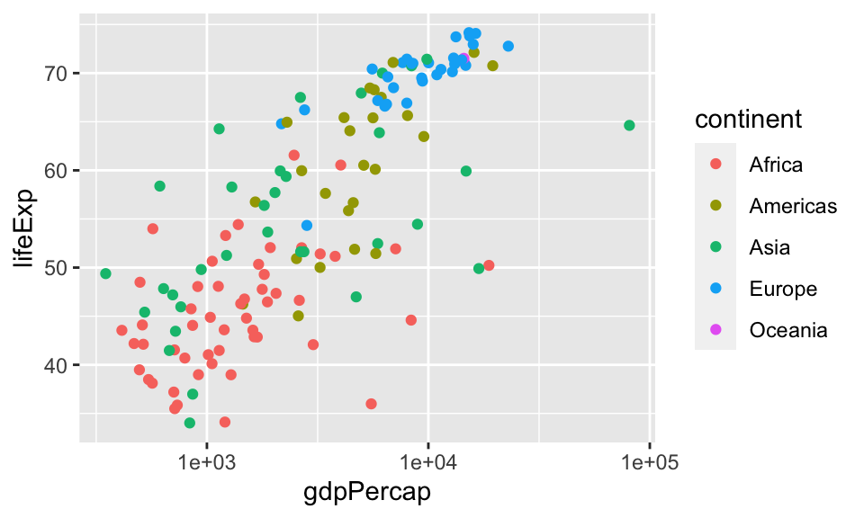

```r
ggplot(gapminder67, mapping = aes(x = gdpPercap, y = lifeExp, color = continent) ) +   #<<
     geom_point() +
     scale_x_log10()
```

## Representamos el continente

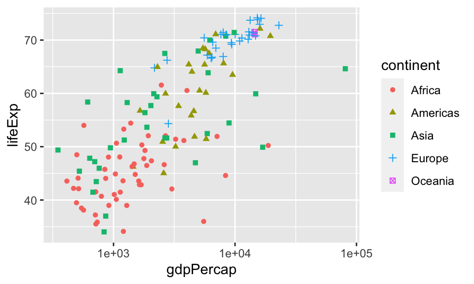

```r
ggplot(gapminder67, mapping = aes(x = gdpPercap, y = lifeExp, color = continent,  #<<
                        shape = continent) ) +   #<<
     geom_point() +
     scale_x_log10()
```

## Representamos el continente y la población

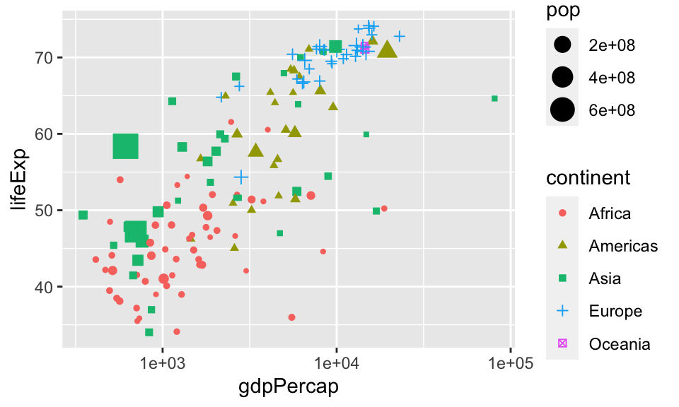

```r
ggplot(gapminder67, mapping = aes(x = gdpPercap, y = lifeExp, color = continent,  #<<
                        shape = continent, size = pop) ) +   #<<
     geom_point() +
     scale_x_log10()
```

## Representamos el continente y la población

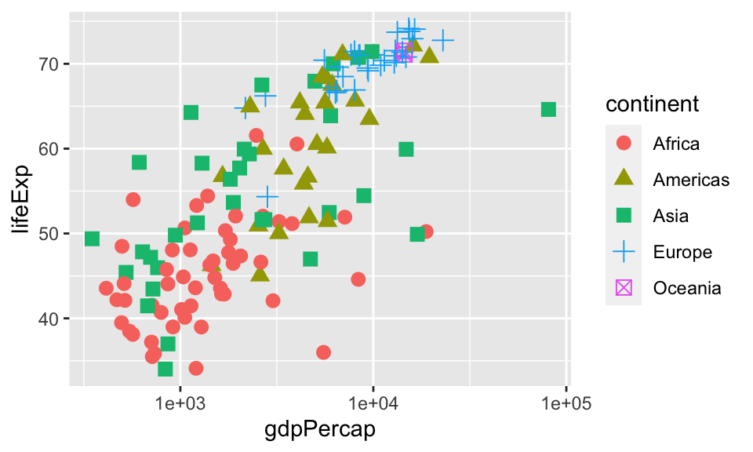

```r
ggplot(gapminder67, mapping = aes(x = gdpPercap, y = lifeExp, color = continent,
                        shape = continent, size = pop) ) +
     geom_point(size=3) +  #<<
     scale_x_log10()
```

## Resumen

- Variables contínuas
- Variables discretas

| aesthetics | discreta | contínua |
| --- | --- | --- |
| color | diferentes colores | gradiente |
| size | pasos discretros | mapeo linear entre variable y radio |
| shape | diferentes formas | no funciona |

`aes` para representar variables usando características del gráfico

`geom_xxx` para definir característica del gráfico

# Visualización: Faceting

## Faceting

Múltiples gráficas en función de variable

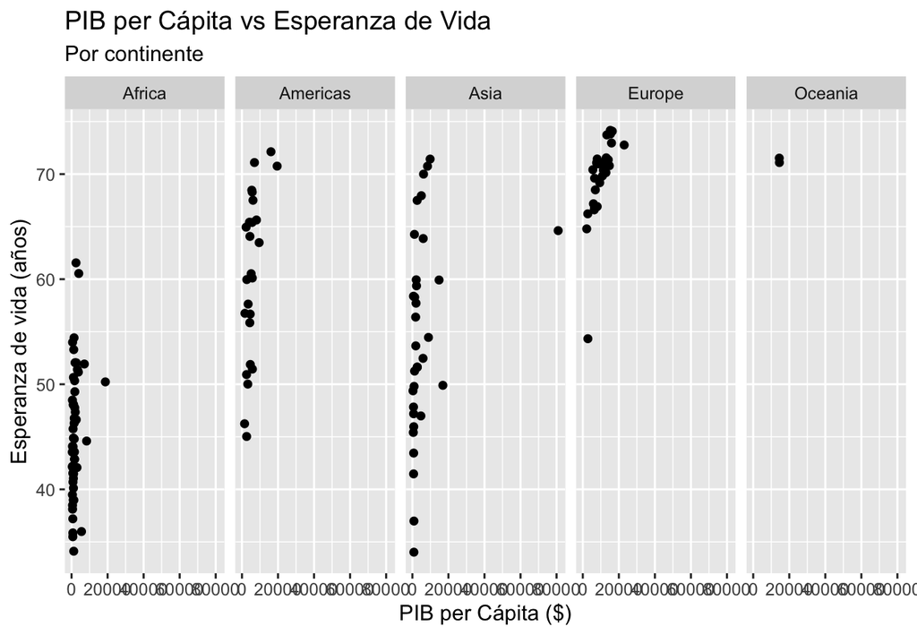

```r
ggplot(data = gapminder67, aes(x = gdpPercap, y = lifeExp)) +
  geom_point() +
  labs(title = "PIB per Cápita vs Esperanza de Vida",
       subtitle = "Por continente",
       x = "PIB per Cápita ($)", y =  "Esperanza de vida (años)") +
  facet_grid(. ~ continent)  #<<
```

## Faceting

Múltiples gráficas en función de variable

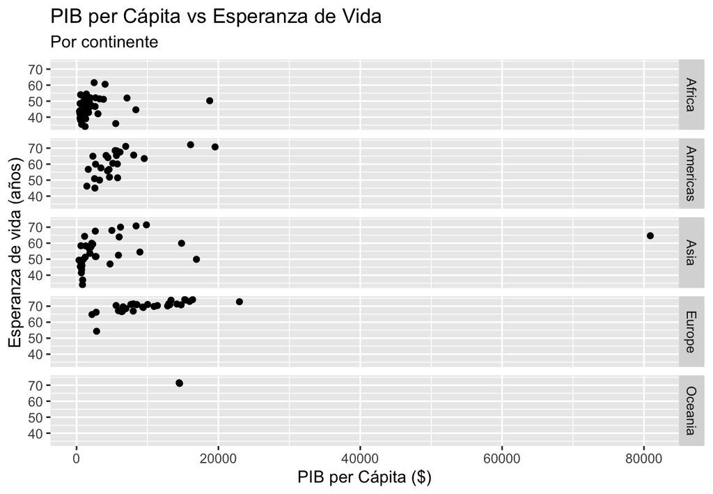

```r
ggplot(data = gapminder67, aes(x = gdpPercap, y = lifeExp)) +
  geom_point() +
  labs(title = "PIB per Cápita vs Esperanza de Vida",
       subtitle = "Por continente",
       x = "PIB per Cápita ($)", y =  "Esperanza de vida (años)") +
  facet_grid(continent ~ .)  #<<
```

## Faceting

Múltiples gráficas en función de variable

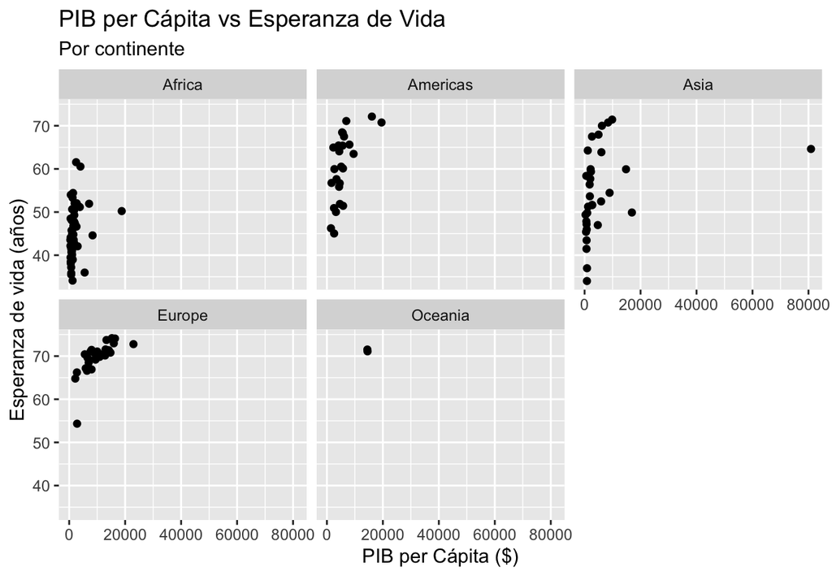

```r
ggplot(data = gapminder67, aes(x = gdpPercap, y = lifeExp)) +
  geom_point() +
  labs(title = "PIB per Cápita vs Esperanza de Vida",
       subtitle = "Por continente",
       x = "PIB per Cápita ($)", y =  "Esperanza de vida (años)") +
  facet_wrap(continent ~ .)  #<<
```

## Faceting

Múltiples gráficas en función de variable

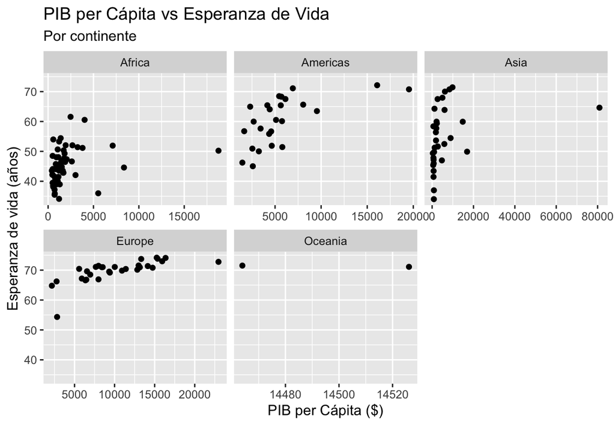

```r
ggplot(data = gapminder67, aes(x = gdpPercap, y = lifeExp)) +
  geom_point() +
  labs(title = "PIB per Cápita vs Esperanza de Vida",
       subtitle = "Por continente",
       x = "PIB per Cápita ($)", y =  "Esperanza de vida (años)") +
  facet_wrap(continent ~ ., scales = "free_x")  #<<
```

# Faceting - Resumen

- `facet_grid()`:
  - Red 2d
  - `filas ~ columnas`
  - `.` para evitar una de ellas
- `facet_wrap()`: 1d
  - fijar escalas con `scales =` (“free_x”, “free_y”, “free”)

## Ejercicio 1

Utilizando los datos de la librería `gapminder`:

- Filtra las obserevaciones correspondientes a los años 1957, 1967, 1977, 1987, 1997, 2007
- Representa la relación entre PIB per cápita y esperanza de vida por continentes y por años en diferentes gráficas usando **faceting**. El tamaño de los puntos ha de ser proporcional a la población. El color debe reflejar el continente.
- ¿Qué conlusiones extraes?

# Visualización: distintos tipos de datos

## Número de variables a visualizar

- **Análisis de datos univariante**: distribución de una variable
- **Análisis de datos bivariante**: relación entre dos variables
- **Análisis de datos multivariantes**: relación entre varias variables, generalmente enfocándose en dos y condicionando por el resto

## Tipos de variables

- **Variables numéricas** pueden ser **contínuas** o **discretas**
  - *altura* es ?
  - *número de cigarros diarios* es ?
  - *distancia* es ?
- **Variables categóricas**, a su vez incluyen **ordinales** si existe un orden natural entre sus niveles o **no ordinales**
  - *color de ojos* es ?
  - *talla de camiseta* es ?

Según tipo de variable tendremos un tipo de representación

# Visualización: datos univariantes numéricos

## ¿Cómo podemos describir datos númericos univariantes?

- **Forma:**
  - asimetría: simétrico, asimétrico a la derecha, asimétrica a la izquierda
  - número de modas: unimodal, bimodal, multimodal, uniforme
- **Centralidad:** media, mediana, moda
- **Dispersión:** rango, desviación estándar, rango inter-cuartílico
- **Outliers:** existen datos raros

## ¿Por qué visualizarlos?

```r
library(Tmisc)
```

[output not shown]

## ¿Por qué visualizarlos?

[output not shown]

## Resumiendo Anscombe’s quartet

```r
quartet %>%
  group_by(set) %>%
  summarise(
    mean_x = mean(x), mean_y = mean(y),
    sd_x = sd(x), sd_y = sd(y),
    r = cor(x, y)
  )
```

```
## # A tibble: 4 × 6
##   set   mean_x mean_y  sd_x  sd_y     r
##   <fct>  <dbl>  <dbl> <dbl> <dbl> <dbl>
## 1 I          9   7.50  3.32  2.03 0.816
## 2 II         9   7.50  3.32  2.03 0.816
## 3 III        9   7.5   3.32  2.03 0.816
## 4 IV         9   7.50  3.32  2.03 0.817
```

## Visualizando Anscombe’s quartet

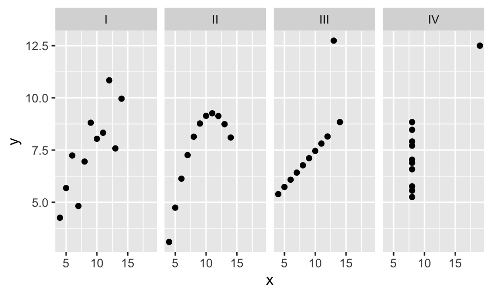

```r
ggplot(quartet, aes(x = x, y = y)) +
  geom_point() +
  facet_wrap(~ set, ncol = 4)
```

## Visualizando datos numéricos univariantes

Histograma - ¿Qué revela este gráfico? (Apuestas…)

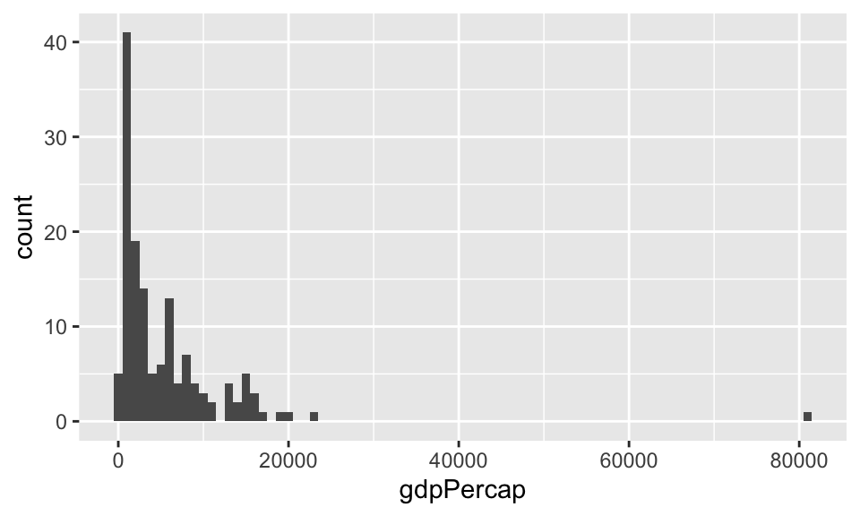

```r
ggplot(gapminder67, mapping = aes(x = gdpPercap)) +
     geom_histogram(binwidth = 1000) #<<
```

## Visualizando datos numéricos univariantes

Histograma - ¿Qué revela este gráfico? (Apuestas…)

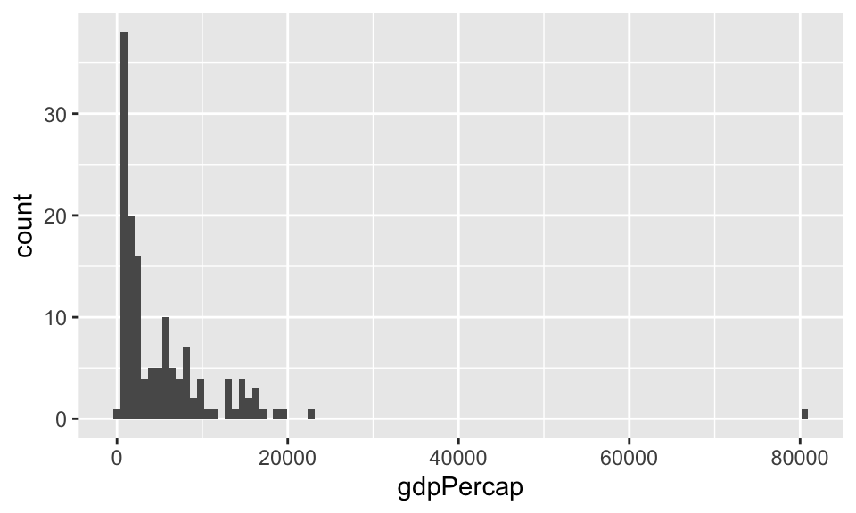

```r
ggplot(gapminder67, mapping = aes(x = gdpPercap)) +
     geom_histogram(bins = 100) #<<
```

## Visualizando datos numéricos univariantes

A veces útil

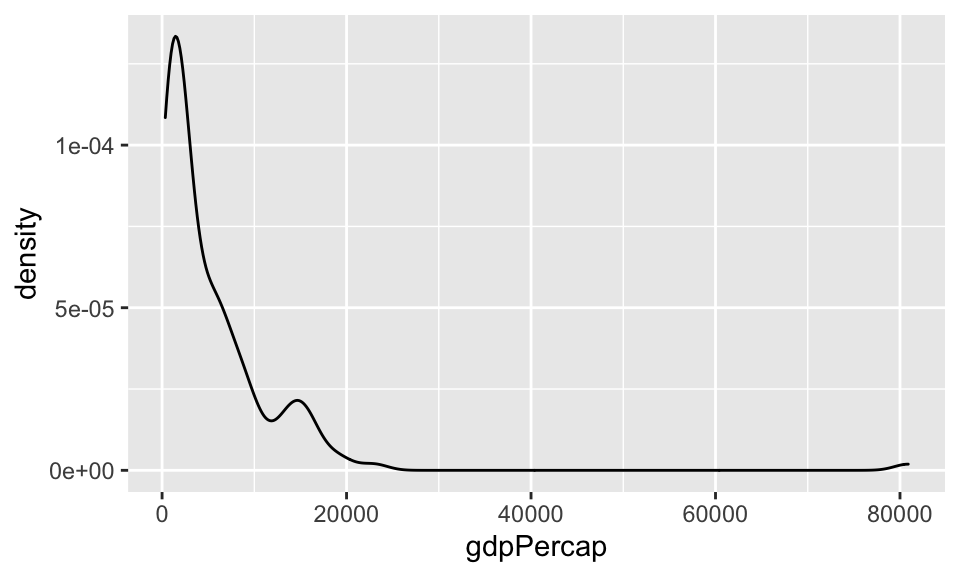

```r
ggplot(gapminder67, mapping = aes(x = gdpPercap)) +
     geom_density() #<<
```

## Visualización: datos univariantes categóricos

## Visualización de datos univariantes categóricos

Gráfico de barras

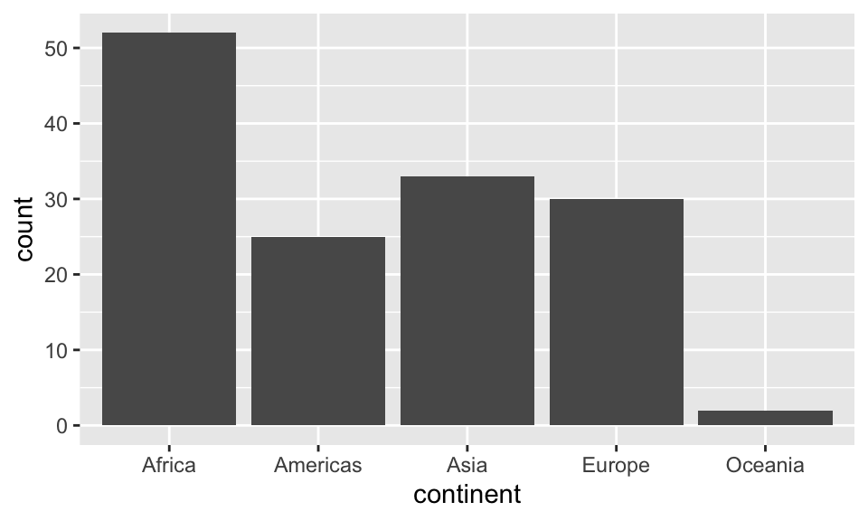

```r
ggplot(gapminder67, mapping = aes(x = continent)) +
  geom_bar() #<<
```

## Visualización: datos bivariantes

## Visualización: datos bivariantes contínuo - categórico

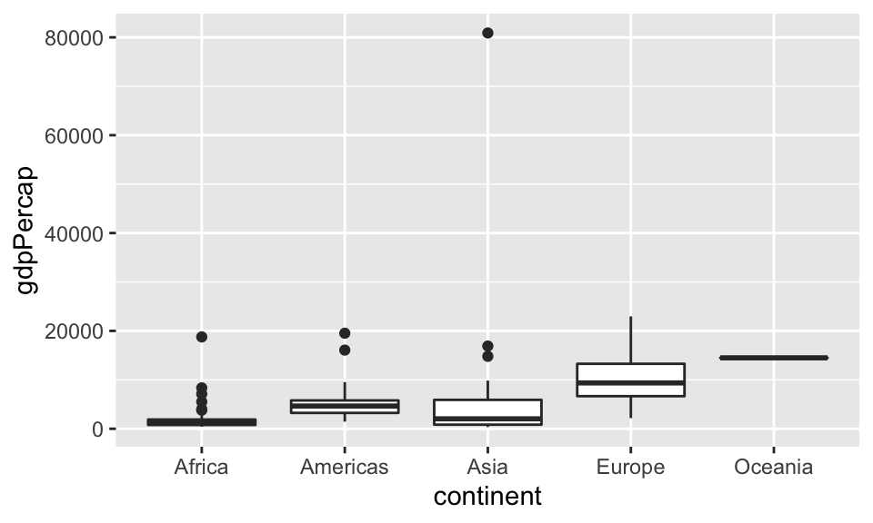

```r
ggplot(gapminder67, mapping = aes(x = continent, y = gdpPercap)) +
  geom_boxplot() #<<
```

## Visualización: datos bivariantes contínuo - categórico

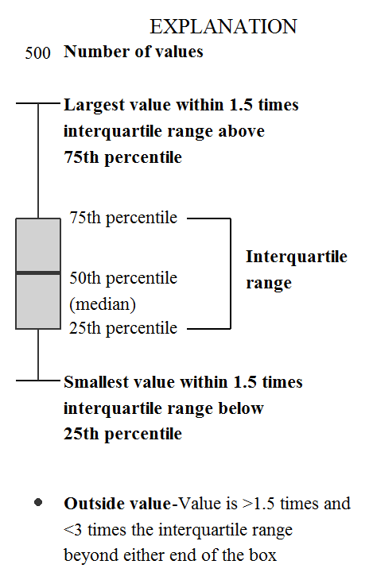

## Visualización: datos bivariantes contínuo - continuo

A veces queda bien añadir un ajuste

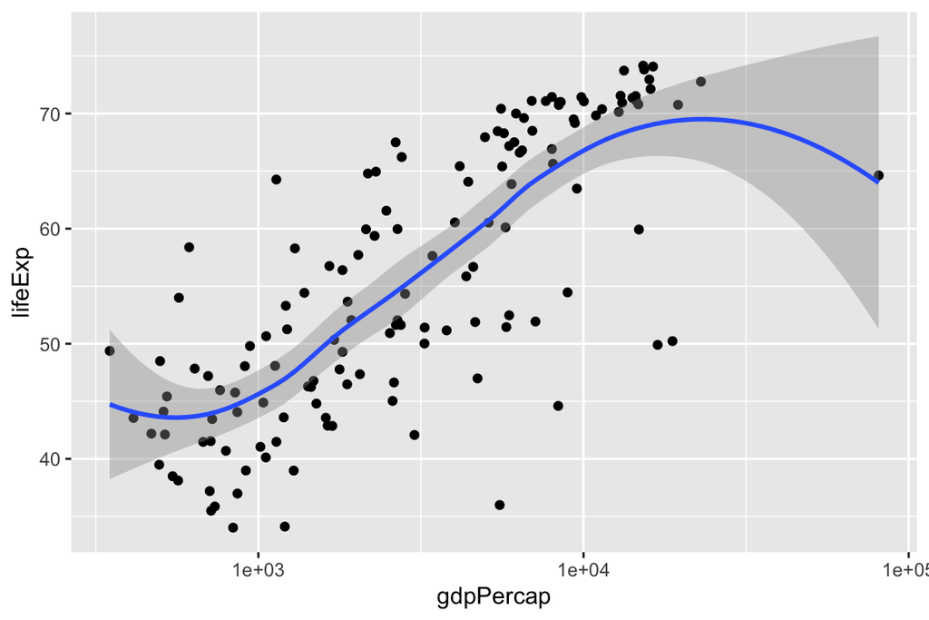

```r
ggplot(gapminder67, aes(x = gdpPercap, y = lifeExp) ) +
     geom_point() +
     scale_x_log10() +
     geom_smooth() #<<
```

## Visualización: datos bivariantes categórico - categórico

Dataset `diamonds`

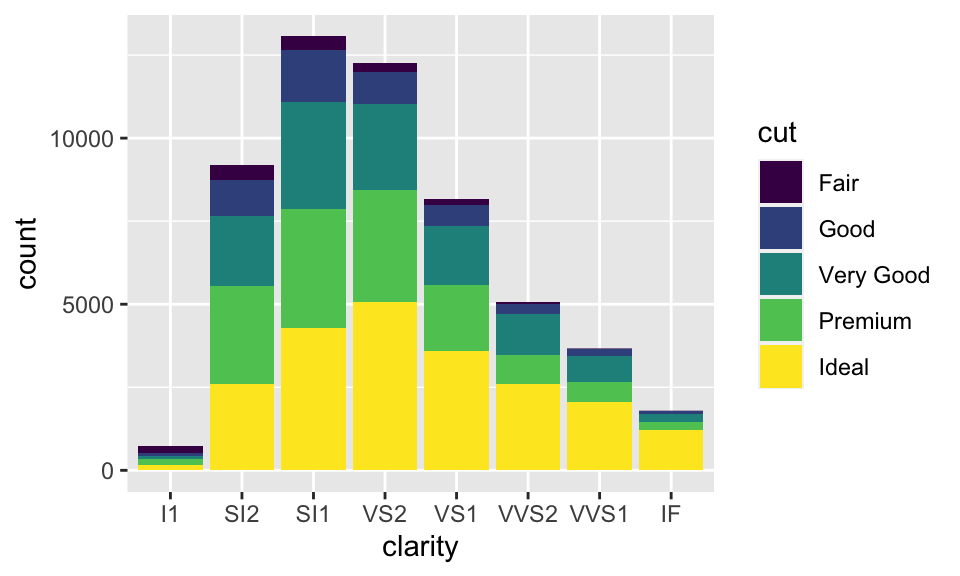

```r
ggplot(data = diamonds, mapping = aes(x = clarity, fill = cut)) +
  geom_bar()  #<<
```

## Visualización: datos bivariantes categórico - categórico

Dataset `diamonds`

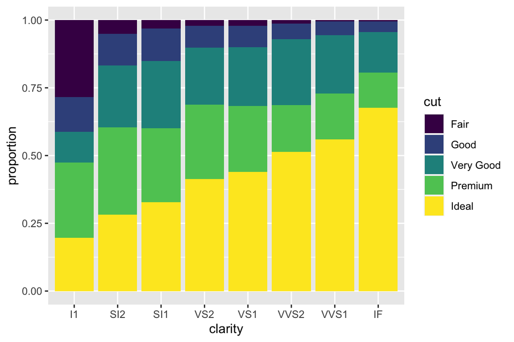

```r
ggplot(data = diamonds, mapping = aes(x = clarity, fill = cut)) +
  geom_bar(position = "fill") + #<<
  labs(y = "proportion")
```

## Visualización: transformaciones estadísticas

## Transformaciones estadísticas

Los gráficos como histogramas, gráficos de barras o boxplots realizan transformaciones a los datos antes de representarlos

- Gráficos de barras e histogramas: parcelan los datos y representan un número por cada parcela
- Smoothers: ajustan un modelo y representan predicciones generadas por el mismo
- Boxplots: calculan un resumen de la distribución y lo pintan en determinado formato

El argumento para especificar el estadistico de resumen es `stat`. Puedes ver su valor por defect en, e.g. `?geom_bar`

## Transformaciones estadísticas

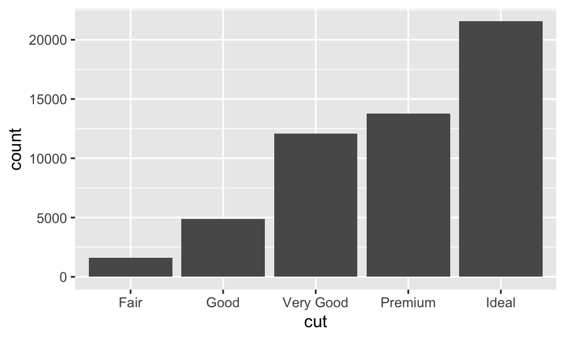

```r
ggplot(data = diamonds) +
  geom_bar(mapping = aes(x = cut))  #<<
```

## Transformaciones estadísticas

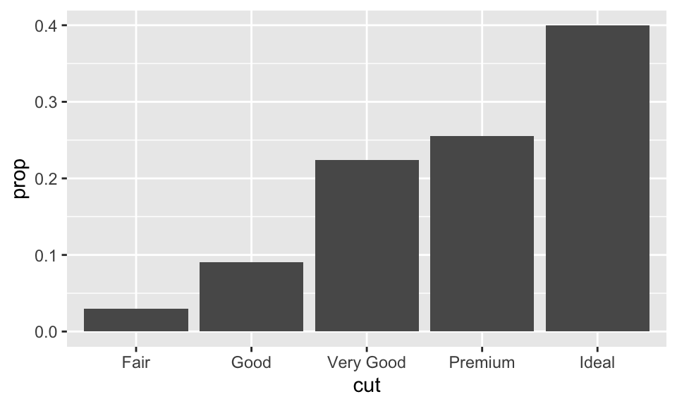

```r
ggplot(data = diamonds) +
  geom_bar(mapping = aes(x = cut, y = stat(prop), group = 1) )  #<<
```

## Transformaciones estadísticas

Podemos crear estadísticos propios

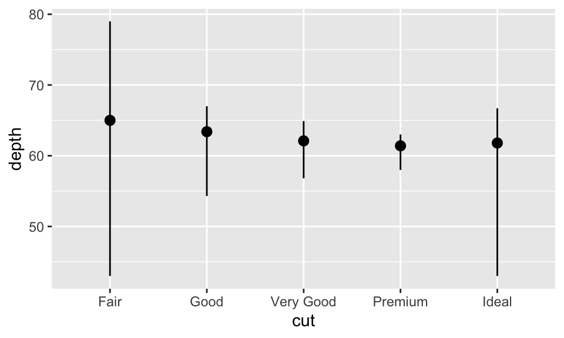

```r
ggplot(data = diamonds) +
  stat_summary( #<<
    mapping = aes(x = cut, y = depth), #<<
    fun.min = min, #<<
    fun.max = max, #<<
    fun = median #<<
  )
```

## Visualización: ajuste de posición

## Ajustes de posición

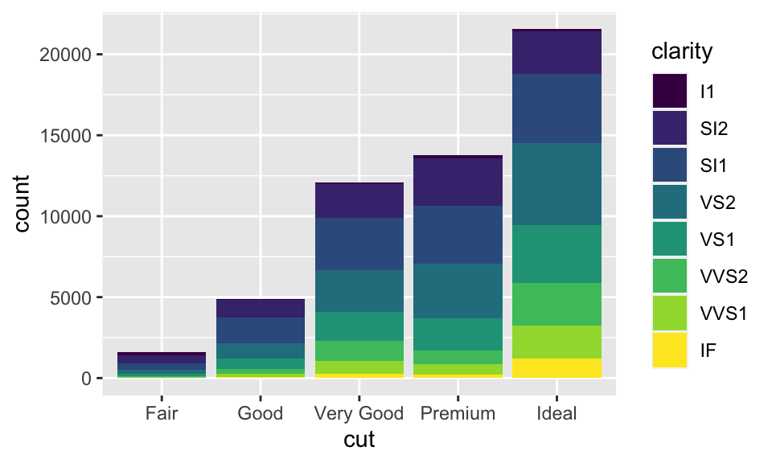

```r
ggplot(data = diamonds) +
  geom_bar(mapping = aes(x = cut, fill = clarity) )
```

El apilamiento se realiza automáticamente con el ajuste de posición especificado a través de la variable `position`

## Ajustes de posición - “identity”

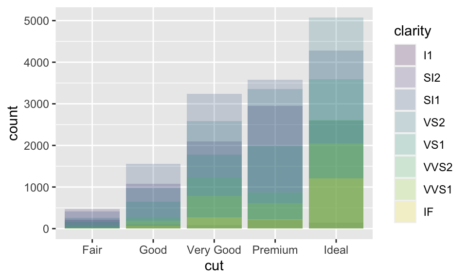

```r
ggplot(data = diamonds, mapping = aes(x = cut, fill = clarity)) +
  geom_bar(alpha = 1/5, position = "identity") #<<
```

## Ajustes de posición - “fill”

¿Para qué es bueno este tipo de gráfico?

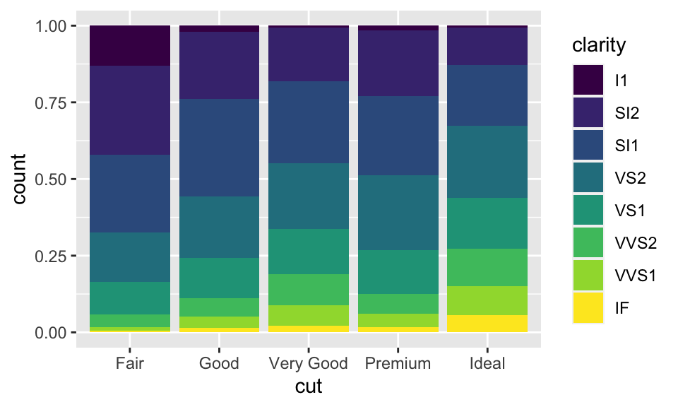

```r
ggplot(data = diamonds, mapping = aes(x = cut, fill = clarity)) +
  geom_bar(position = "fill") #<<
```

## Ajustes de posición - “dodge”

¿Y este?

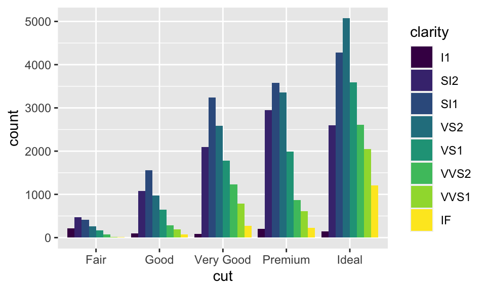

```r
ggplot(data = diamonds, mapping = aes(x = cut, fill = clarity)) +
  geom_bar(position = "dodge") #<<
```

## Visualización: coordenadas

## Coordenadas

Por defecto `ggplot2` usa coordenadas Cartesianas. Las coordenadas pueden modificarse con `coord_xxx()`

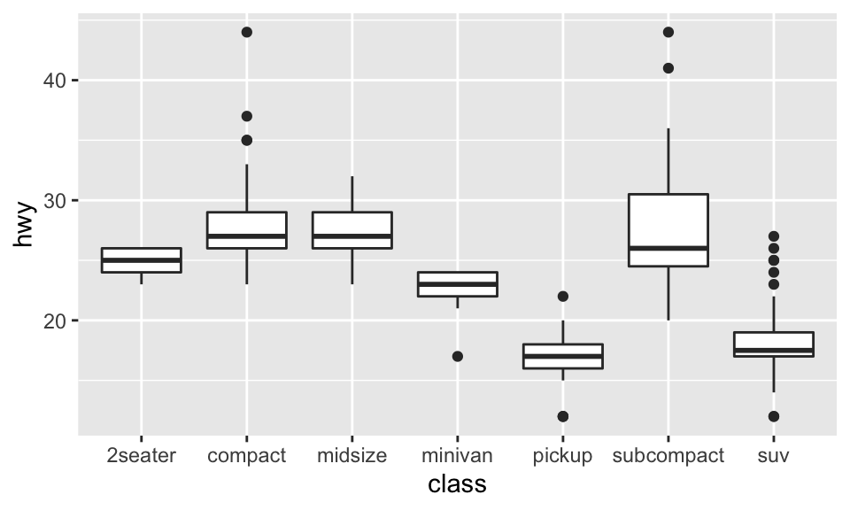

```r
ggplot(data = mpg, mapping = aes(x = class, y = hwy)) +
  geom_boxplot()
```